# Probability Fundamentals

Lecture 03

January 29, 2025

# Review

## Null Hypothesis Significance Testing

- Binary “significant”/“non-significant” decision framework;
- Accept or reject null hypothesis $\mathcal{H}_0$ based on p-value of test statistic (relative to significance level $\alpha$);
- “Typical” statistical models for $\mathcal{H}_0$ often chosen out of computational convenience
- **There be dragons**: Multiple comparisons, lack of statistical power, reading rejection of $\mathcal{H}_0$ as acceptance of alternative $\mathcal{H}$

## What NHST Means (and Doesn’t)

- **Rejection of $\mathcal{H}_0$ does not mean $\mathcal{H}$ is true**
- Not rejecting $\mathcal{H}_0$ does not mean $\mathcal{H}$ is false.
- Says nothing about $p(\mathcal{H}_0 | y)$
- “Simply” a measure of surprise at seeing data under null model.

# Probability “Review”

## What is Uncertainty?

> …A departure from the (unachievable) ideal of complete determinism…

— Walker et al. (2003)

## Types of Uncertainty

| Uncertainty Type | Source | Example(s) |
| --- | --- | --- |
| *Aleatory uncertainty* | Randomness | Dice rolls, Instrument imprecision |
| *Epistemic uncertainty* | Lack of knowledge | Climate sensitivity, Premier League champion |

[figure not shown]

Which Uncertainty Type Meme

## Probability

Probability is a language for expressing uncertainty.

The **axioms of probability** are straightforward:

1. $\mathcal{P}(E) \geq 0$;
2. $\mathcal{P}(\Omega) = 1$;
3. $\mathcal{P}(\cup_{i=1}^\infty E_i) = \sum_{i=1}^\infty \mathcal{P}(E_i)$ for disjoint $E_i$.

## Frequentist vs Bayesian Probability

**Frequentist**:

- Probability as frequency over repeated observations.
- Data are random, but parameters are not.
- How consistent are estimates for different data?

**Bayesian**:

- Probability as degree of belief/betting odds.
- Data and parameters are random variables;
- Emphasis on **conditional probability**.

## But What, Like, **Is** Probability?

Frequentist vs. Bayesian: different interpretations with some different methods and formalisms.

We will freely borrow from each school depending on the purpose and goal of an analysis.

[figure not shown]

Definitions of Probability Meme

## Probability Distributions

Distributions are mathematical representations of probabilities over a range of possible outcomes.

$$x \to \mathbb{P}_{\color{green}\mathcal{D}}[x] = p_{\color{green}\mathcal{D}}\left(x | {\color{purple}\theta}\right)$$

- ${\color{green}\mathcal{D}}$: probability distribution (often implicit);
- ${\color{purple}\theta}$: distribution parameters

## Sampling Notation

To write $x$ is sampled from $\mathcal{D}(\theta) = p(x|\theta)$:
$$x \sim \mathcal{D}(\theta)$$

For example, for a normal distribution:
$$x \overset{\text{i.i.d.}}{\sim} \mathcal{N}(\mu, \sigma)$$

## Probability Density Function

A continuous distribution $\mathcal{D}$ has a probability density function (PDF) $f_\mathcal{D}(x) = p(x | \theta)$.

The probability of $x$ occurring in an interval $(a, b)$ is
$$\mathbb{P}[a \leq x \leq b] = \int_a^b f_\mathcal{D}(x)dx.$$

**Important**: $\mathbb{P}(x = x^*)$ is zero!

## Probability Mass Functions

Discrete distributions have *probability mass functions* (PMFs) which are defined at point values, e.g. $p(x = x^*) \neq 0$.

## Cumulative Density Functions

If $\mathcal{D}$ is a distribution with PDF $f_\mathcal{D}(x)$, the **cumulative density function** (CDF) of $\mathcal{D}$ is $F_\mathcal{D}(x)$:

$$F_\mathcal{D}(x) = \int_{-\infty}^x f_\mathcal{D}(u)du.$$

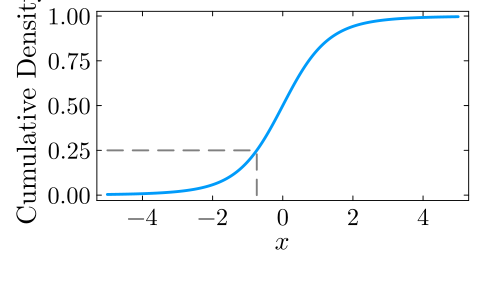

(a) Relationship of CDF and PDF

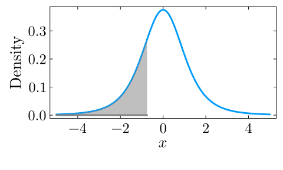

(b)

Figure 1

## Relationship Between PDFs and CDFs

Since
$$F_\mathcal{D}(x) = \int_{-\infty}^x f_\mathcal{D}(u)du,$$

if $f_\mathcal{D}$ is continuous at $x$, the Fundamental Theorem of Calculus gives:
$$f_\mathcal{D}(x) = \frac{d}{dx}F_\mathcal{D}(x).$$

## Quantiles

The quantile function is the **inverse of the CDF**:

$$q(\alpha) = F^{-1}_\mathcal{D}(\alpha)$$

So
$$x_0 = q(\alpha) \iff \mathbb{P}_\mathcal{D}(X < x_0) = \alpha.$$

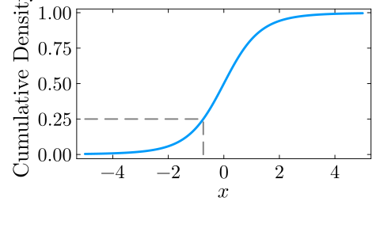

(a) Relationship of CDF and PDF

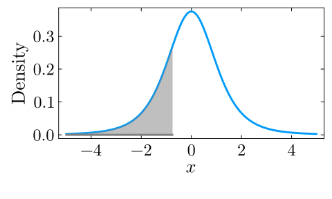

(b)

Figure 2

# Selecting a Distribution

## Distributions Are Assumptions

**Specifying a distribution is making an assumption about observations and any applicable constraints.**

Examples: If your observations are…

- Continuous and fat-tailed? **Cauchy distribution**
- Continuous and bounded? **Beta distribution**
- Sums of positive random variables? **Gamma or Normal distribution**.

## Why Use a Normal Distribution?

Two main reasons to use linear models/normal distributions:

1. **Inferential**: “Least informative” distribution assuming knowledge of just mean and variance;
2. **Generative**: Central Limit Theorem (summed fluctuations are asymptotically normal)

[figure not shown]

Weight stack Gaussian distribution

Source: r/GymMemes

## Statistics of Random Variables are Random Variables

**The sum or mean of a random sample is itself a random variable**:

$$\bar{X}_n = \frac{1}{n}\sum_{i=1}^n X_i \sim \mathcal{D}_n$$

$\mathcal{D}_n$: The *sampling distribution* of the mean (or sum, or other estimate of interest).

## Sampling Distributions

[figure not shown]

Illustration of the Sampling Distribution

## Central Limit Theorem

If

- $\mathbb{E}[X_i] = \mu$
- and $\text{Var}(X_i) = \sigma^2 < \infty$,

$$\begin{align*}
&\bbox[yellow, 10px, border:5px solid red]
{\lim_{n \to \infty} \sqrt{n}(\bar{X}_n - \mu ) = \mathcal{N}(0, \sigma^2)} \\
\Rightarrow &\bbox[yellow, 10px, border:5px solid red] {\bar{X}_n \overset{\text{approx}}{\sim} \mathcal{N}(\mu, \sigma^2/n)}
\end{align*}$$

## Central Limit Theorem (More Intuitive)

For **a large enough set of samples**, the sampling distribution of a sum or mean of random variables is approximately a normal distribution, even if the random variables themselves are not.

[figure not shown]

Small n Meme

Source: Unknown

## “What Distribution Should I Use?”

**There is no right answer to this, no matter what a statistical test tells you.**

- What assumptions are justifiable from theory?
- What information do you have?

## “What Distribution Should I Use?”

For example, suppose our data are counts of events:

- If you know something about **rates**, you can use a Poisson distribution
- If you know something about **probabilities**, you can use a Binomial distribution.

## Q-Q Plots

One exploratory method to see if your data is reasonably described by a theoretical distribution is a **Q-Q plot**.

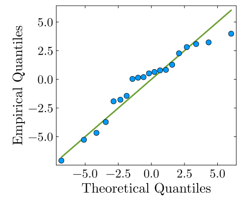

Figure 3

```julia
samps = rand(Normal(0, 3), 20)
qqplot(Normal, samps, tickfontsize=16, guidefontsize=18, linewidth=3, markersize=6)
xlabel!("Theoretical Quantiles")
ylabel!("Empirical Quantiles")
plot!(size=(500, 450))
```

## Fat-Tailed Data and Q-Q Plots

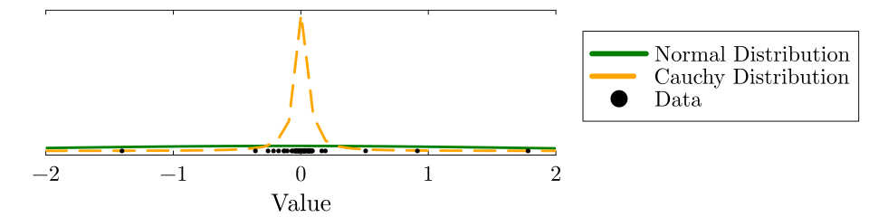

(a) Normal vs Cauchy Distribution

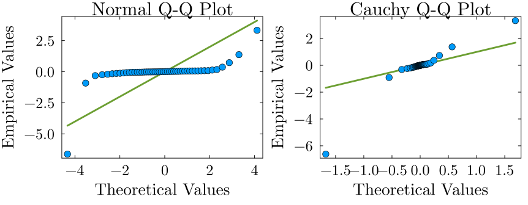

(b) Q-Q Plot

Figure 4: Q-Q Plot for Cauchy Data and Normal Distribution

# Maximum Likelihood

## Likelihood

How do we “fit” distributions to a dataset?

**Likelihood** of data to have come from distribution $f(\mathbf{x} | \theta)$:

$$\mathcal{L}(\theta | \mathbf{x}) = \underbrace{f(\mathbf{x} | \theta)}_{\text{PDF}}$$

## Normal Distribution PDF

$$f_\mathcal{D}(x) = p(x | \mu, \sigma) = \frac{1}{\sigma\sqrt{2\pi}} \exp\left(-\frac{1}{2}\left(\frac{x - \mu}{\sigma}^2\right)\right)$$

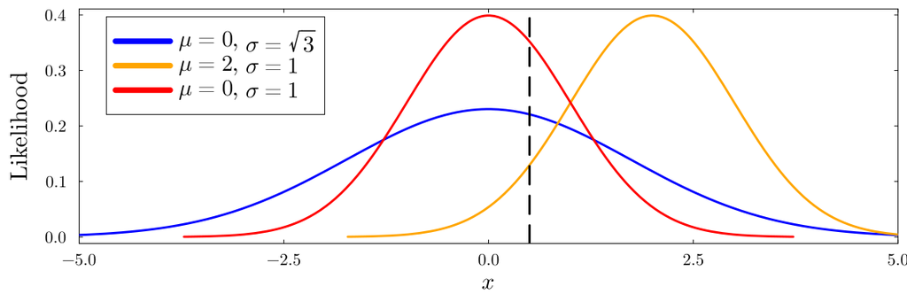

Figure 5

## Likelihood of Multiple Samples

For multiple (independent) samples $\mathbf{x} = \{x_1, \ldots, x_n\}$:

$$\mathcal{L}(\theta | \mathbf{x}) = \prod_{i=1}^n \mathcal{L}(\theta | x_i).$$

## Likelihood Example

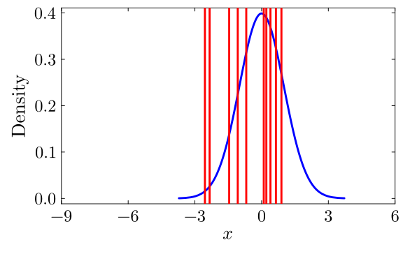

| Distribution | Likelihood |
| --- | --- |
| $N(0, 1)$ | 1.9e-8 |

## Likelihood Example

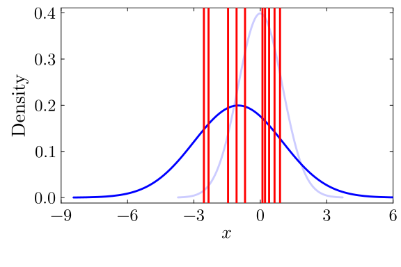

| Distribution | Likelihood |
| --- | --- |
| $N(0, 1)$ | 1.9e-8 |
| $N(-1, 2)$ | 1.5e-8 |

## Likelihood Example

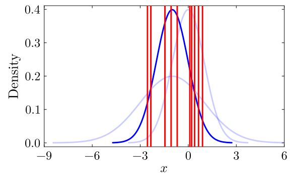

| Distribution | Likelihood |
| --- | --- |
| $N(0, 1)$ | 1.9e-8 |
| $N(-1, 2)$ | 1.5e-8 |
| $N(-1, 1)$ | 4.6e-8 |

## Maximizing Likelihood

To find the parameters $\hat{\theta}$ which best fit the data:

$\hat{\theta} = \max_\theta \mathcal{L}(\theta | \mathbf{x})$

## Generally Maximizing Likelihood

Can use optimization algorithms to maximize $\theta \to \mathcal{L}(\theta | x).$

**Dragons**: Probability calculations tend to under- and overflow due to floating point precision.

[figure not shown]

Floating Point Logarithms meme

# Describing Uncertainty

## Confidence Intervals

Frequentist estimates have **confidence intervals**, which will contain the “true” parameter value for $\alpha$% of data samples.

No guarantee that an individual CI contains the true value (with any “probability”)!

[figure not shown]

Horseshoe Illustration

Source: https://www.wikihow.com/Throw-a-Horseshoe

## Example: 95% CIs for N(0.4, 2)

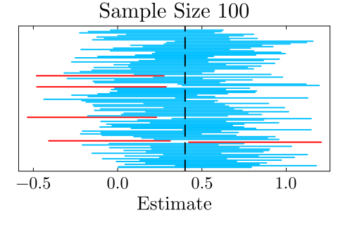

(a) Sample Size 100

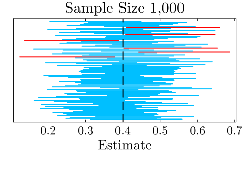

(b) Sample Size 1,000

Figure 6: Display of 95% confidence intervals

```julia
# set up distribution
mean_true = 0.4
n_cis = 100 # number of CIs to compute
dist = Normal(mean_true, 2)

# use sample size of 100
samples = rand(dist, (100, n_cis))
# mapslices broadcasts over a matrix dimension, could also use a loop
sample_means = mapslices(mean, samples; dims=1)
sample_sd = mapslices(std, samples; dims=1)
mc_sd = 1.96 * sample_sd / sqrt(100)
mc_ci = zeros(n_cis, 2) # preallocate
for i = 1:n_cis
    mc_ci[i, 1] = sample_means[i] - mc_sd[i]
    mc_ci[i, 2] = sample_means[i] + mc_sd[i]
end
# find which CIs contain the true value
ci_true = (mc_ci[:, 1] .< mean_true) .&& (mc_ci[:, 2] .> mean_true)
# compute percentage of CIs which contain the true value
ci_frac1 = 100 * sum(ci_true) ./ n_cis

# plot CIs
p1 = plot([mc_ci[1, :]], [1, 1], linewidth=3, color=:deepskyblue, label="95% Confidence Interval", title="Sample Size 100", yticks=:false, legend=:false)
for i = 2:n_cis
    if ci_true[i]
        plot!(p1, [mc_ci[i, :]], [i, i], linewidth=2, color=:deepskyblue, label=:false)
    else
        plot!(p1, [mc_ci[i, :]], [i, i], linewidth=2, color=:red, label=:false)
    end
end
vline!(p1, [mean_true], color=:black, linewidth=2, linestyle=:dash, label="True Value") # plot true value as a vertical line
xaxis!(p1, "Estimate")
plot!(p1, size=(500, 350)) # resize to fit slide

# use sample size of 1000
samples = rand(dist, (1000, n_cis))
# mapslices broadcasts over a matrix dimension, could also use a loop
sample_means = mapslices(mean, samples; dims=1)
sample_sd = mapslices(std, samples; dims=1)
mc_sd = 1.96 * sample_sd / sqrt(1000)
mc_ci = zeros(n_cis, 2) # preallocate
for i = 1:n_cis
    mc_ci[i, 1] = sample_means[i] - mc_sd[i]
    mc_ci[i, 2] = sample_means[i] + mc_sd[i]
end
# find which CIs contain the true value
ci_true = (mc_ci[:, 1] .< mean_true) .&& (mc_ci[:, 2] .> mean_true)
# compute percentage of CIs which contain the true value
ci_frac2 = 100 * sum(ci_true) ./ n_cis

# plot CIs
p2 = plot([mc_ci[1, :]], [1, 1], linewidth=3, color=:deepskyblue, label="95% Confidence Interval", title="Sample Size 1,000", yticks=:false, legend=:false)
for i = 2:n_cis
    if ci_true[i]
        plot!(p2, [mc_ci[i, :]], [i, i], linewidth=2, color=:deepskyblue, label=:false)
    else
        plot!(p2, [mc_ci[i, :]], [i, i], linewidth=2, color=:red, label=:false)
    end
end
vline!(p2, [mean_true], color=:black, linewidth=2, linestyle=:dash, label="True Value") # plot true value as a vertical line
xaxis!(p2, "Estimate")
plot!(p2, size=(500, 350)) # resize to fit slide

display(p1)
display(p2)
```

## Predictive Intervals

**Predictive intervals** capture uncertainty in an estimand.

**With what probability would I see a particular outcome in the future?**

Often need to construct these using **simulation**.

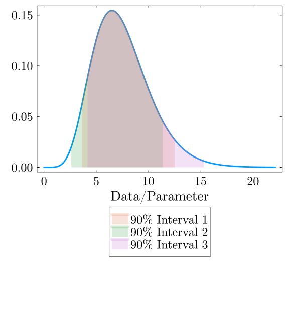

## OLS Estimate of Regression Coefficients

Write regression as
$$\mathbf{y} = \mathbf{X} \beta.$$

Goal is to minimize the squared error:

$$\hat{\mathbf{\beta}} = \underset{\beta}{\operatorname{argmin}} S(\beta),$$

where
$$S(\beta) = \sum_{i=1}^n \left|y_i - \sum_{j=1}^p X_{ij} \beta_j\right|^2 = \|\mathbf{y} - \mathbf{X}\mathbf{\beta}\|^2.$$

## OLS Solution

If the columns of $\mathbf{X}$ are linearly independent, the solution is:

$$\hat{\beta} = \left(\mathbf{X}^T\mathbf{X}\right)^{-1}\mathbf{X}^T \mathbf{y}.$$

Estimate of the variance:

$$\sigma^2_\text{OLS} = \frac{S(\hat{\mathbf{\beta}})}{n-p}.$$

## Linear Regression Likelihood

How do we find $\beta_i$ and $\sigma$?

**Likelihood** of data to have come from distribution $f(\mathbf{x} | \theta)$:
$$\mathcal{L}(\theta | \mathbf{x}) = \underbrace{f(\mathbf{x} | \theta)}_{\text{PDF}}$$

Here the randomness comes from $U$:
$$S \sim \mathcal{N}(\beta_0 + \beta_1 \log(D), \sigma^2)$$

# OLS vs. Maximum Likelihood

## Maximizing Gaussian Likelihood ⇔ Least Squares

$$y_i \sim \mathcal{N}(F(x_i), \sigma^2)$$

$$\mathcal{L}(\theta | \mathbf{y}; F) = \prod_{i=1}^n \frac{1}{\sqrt{2\pi}} \exp(-\frac{y_i - F(x_i)^2}{2\sigma^2})$$

$$\log \mathcal{L}(\theta | \mathbf{y}; F) = \sum_{i=1}^n \left[\log \frac{1}{\sqrt{2\pi}} - \frac{1}{2\sigma^2}(y_i - F(x_i))^2 \right]$$

$$\begin{aligned}
\log \mathcal{L}(\theta | \mathbf{y}, F) &= \sum_{i=1}^n \left[\log \frac{1}{\sqrt{2\pi}} - \frac{1}{2\sigma^2}(y_i - F(x_i)) ^2 \right] \\
&= n \log \frac{1}{\sqrt{2\pi}} - \frac{1}{2\sigma^2} \sum_{i=1}^n (y_i - F(x_i))^2
\end{aligned}$$

Ignoring constants (including $\sigma$):

$$\log \mathcal{L}(\theta | \mathbf{y}, F) \propto -\sum_{i=1}^n (y_i - F(x_i))^2.$$

Maximizing $f(x)$ is equivalent to minimizing $-f(x)$:

$$-\log \mathcal{L}(\theta | \mathbf{y}, F) \propto \sum_{i=1}^n (y_i - F(x_i))^2 = \text{MSE}$$

**Note**: OLS vs. MLE estimates of $\sigma^2$ can differ by a factor of $\frac{n-p}{n}$.

## Implication of MLE/OLS Equivalence

- Can rely on numerical optimization techniques of the likelihood instead of solving OLS equations.
- Maximizing likelihood generalizes to a broader category of models with more flexible forms (as we will see over the semester).
- Downside: numerical optimization can be finicky! May break down when the likelihood surface is “flat” (next week),

# Example

## How Does River Flow Affect TDS?

**Question**: How does river flow affect the concentration of total dissolved solids?

**Data**: Cuyahoga River (1969 – 1973), from Helsel et al. (2020, Chapter 9).

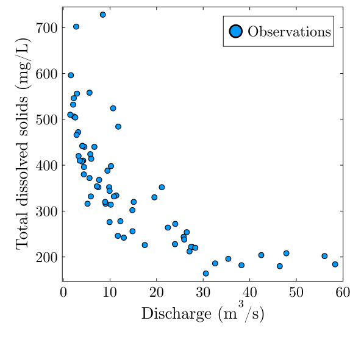

Figure 8: Data

## How Does River Flow Affect TDS?

**Question**: Does river flow affect the concentration of total dissolved solids?

**Model**:
$$D \rightarrow S \ {\color{purple}\leftarrow U}$$
$$S = f(D, U)$$

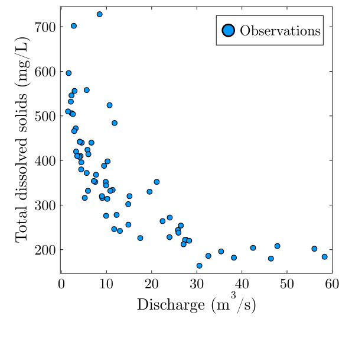

## Log-Linear Relationships

$$\begin{aligned}
S &= \beta_0 + \beta_1 \log(D) + U\\
U &\sim \mathcal{N}(0, \sigma^2)
\end{aligned}$$

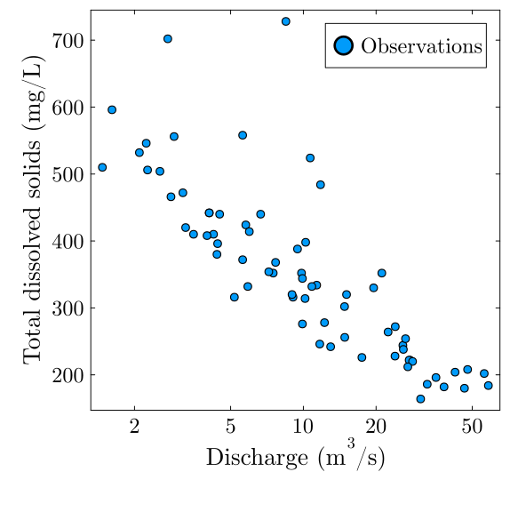

## Optimizing Log-Likelihood

```julia
# tds_riverflow_loglik: function to compute the log-likelihood for the tds model
# θ: vector of model parameters (coefficients β₀ and β₁ and stdev σ)
# tds, flow: vectors of data
function tds_riverflow_loglik(θ, tds, flow)
    β₀, β₁, σ = θ # unpack parameter vector
    μ = β₀ .+ β₁ * log.(flow) # find mean
    ll = sum(logpdf.(Normal.(μ, σ), tds)) # compute log-likelihood
    return ll
end

# set bounds (lb, ub) for the parameters and an initial value (θ₀) for the optimization
lb = [0.0, -1000.0, 1.0]
ub = [1000.0, 1000.0, 100.0]
θ₀ = [500.0, 0.0, 50.0]
# this minimizes the negative log-likelihood
optim_out = Optim.optimize(θ -> -tds_riverflow_loglik(θ, tds.tds_mgL, tds.discharge_cms), lb, ub, θ₀)
θ_mle = round.(optim_out.minimizer; digits=0)
@show θ_mle;
```

```
θ_mle = [610.0, -112.0, 72.0]
```

## Maximum Likelihood Results

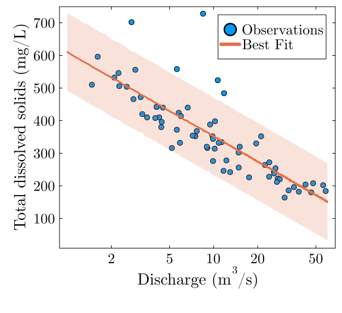

```julia
# simulate 10,000 predictions
x = 1:0.1:60
μ = θ_mle[1] .+ θ_mle[2] * log.(x)

y_pred = zeros(length(x), 10_000)
for i = 1:length(x)
    y_pred[i, :] = rand(Normal(μ[i], θ_mle[3]), 10_000)
end
# take quantiles to find prediction intervals
y_q = mapslices(v -> quantile(v, [0.05, 0.5, 0.95]), y_pred; dims=2)

plot(p1,
    x,
    y_q[:, 2],
    ribbon = (y_q[:, 2] - y_q[:, 1], y_q[:, 3] - y_q[:, 2]),
    linewidth=3,
    fillalpha=0.2,
    label="Best Fit",
    size=(600, 550))
```

# More General Models

## Example: Modeling Counts

```julia
fish = CSV.File("data/ecology/Fish.csv") |> DataFrame
fish[1:3, :]
```

3×6 DataFrame

| Row | fish_caught Int64 | livebait Int64 | camper Int64 | persons Int64 | child Int64 | hours Float64 |
| --- | --- | --- | --- | --- | --- | --- |
| 1 | 0 | 0 | 0 | 1 | 0 | 21.124 |
| 2 | 0 | 1 | 1 | 1 | 0 | 5.732 |
| 3 | 0 | 1 | 0 | 1 | 0 | 1.323 |

## What Distribution?

Count data can be modeled using a Poisson or negative binomial distribution.

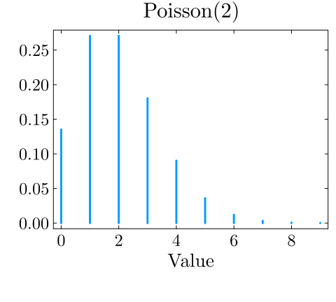

Figure 9: Poisson

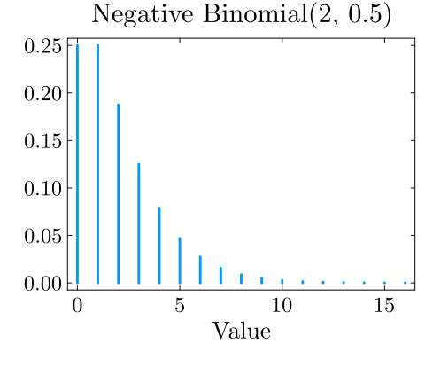

Figure 10: Negative Binomial

## Exploring the Data

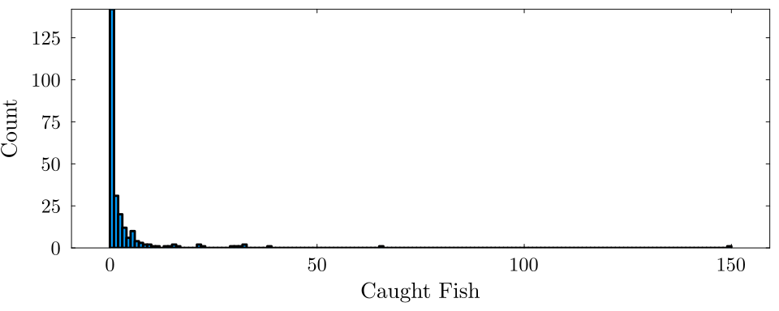

Figure 11: Fishing Data

- Mean: 3.3
- Variance: 135.4

## Model Specification

We might hypothesize that more people fishing for more hours results in a greater chance of catching fish.

$$\begin{align*}
y_i &\sim Poisson(\lambda_i) \\
f(\lambda_i) &= \beta_0 + \beta_1 P_i + \beta_2 H_i
\end{align*}$$

$\lambda_i$: positive “rate”

$f(\cdot)$: maps positive reals (rate scale) to all reals (linear model scale)

## Link Functions

$\color{brown}f$ is the **link function**.

$\color{royalblue}f^{-1}$ is the **inverse link**.

$$\begin{align*}
y_i &\sim Poisson(\lambda_i) \\
{\color{brown}f}(\lambda_i) &= \beta_0 + \beta_1 P_i + \beta_2 H_i
\end{align*}$$

$$\lambda_i = {\color{royalblue}f^{-1}}\left(\beta_0 + \beta_1 P_i + \beta_2 H_i\right)$$

## Choosing a Link Function

Link functions are typically linked to distributions.

- Poisson models usually use the **log link** (positives → reals).
- Binomial/Bernoulli models use the **logit** link ($[0, 1]$ → reals)
  $$\text{logit}(p) = \log\left(\frac{p}{1-p}\right)$$

## Fitting the Model

```julia
function fish_model(params, persons, hours, fish_caught)
    β₀, β₁, β₂ = params
    λ = exp.(β₀ .+ β₁ * persons + β₂ * hours)
    loglik = sum(logpdf.(Poisson.(λ), fish_caught))
end

lb = [-100.0, -100.0, -100.0]
ub = [100.0, 100.0, 100.0]
init = [0.0, 0.0, 0.0]

optim_out = optimize(θ -> -fish_model(θ, fish.persons, fish.hours, fish.fish_caught), lb, ub, init)
θ_mle = optim_out.minimizer
@show round.(θ_mle; digits=1);
```

```
round.(θ_mle; digits = 1) = [-1.5, 0.8, 0.0]
```

## Evaluating Model Fit

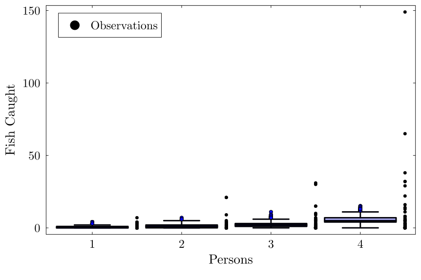

Figure 12: Predictive distribution for fitted fish model.

## What Was The Problem?

- Model neglected other plausible contributors, *e.g.* live bait.
- Data is **over-dispersed**: higher variance than mean.
- Might be better described by a zero-inflated Poisson model:
  - Visitors who spent little time are likely to catch no fish.
  - Visitors who spent more time are likely to catch positive fish.

# Upcoming Schedule

## Next Classes

**Next Week**: Probability Models for Data

## Assessments

**Homework 1** due next Friday (2/7).

**Quiz**: Due before next class.

**Reading**: Annotate/submit writing before next class, will reserve time for discussion.

# References

## References (Scroll for Full List)

Helsel, D. R., Hirsch, R. M., Ryberg, K. R., Archfield, S. A., & Gilroy, E. J. (2020). *Statistical methods in water resources* (research report No. 4-A3) (p. 484). Reston, VA: U.S. Geological Survey. Retrieved from http://pubs.er.usgs.gov/publication/tm4A3

Walker, W. E., Harremoës, P., Rotmans, J., Sluijs, J. P. van der, Asselt, M. B. A. van, Janssen, P., & Krayer von Krauss, M. P. (2003). Defining uncertainty: A conceptual basis for uncertainty management in model-based decision support. *Integrated Assessment*, *4*, 5–17. https://doi.org/10.1076/iaij.4.1.5.16466